# Applying Bayesian Methods

73-423 Forecasting for Economics and Business

## Outline

- Review of Bayesian Theory
- Posterior Computation Approach I: Large sample approximation
  - MAP
  - Laplace approximation
- Posterior Computation Approach II: MCMC Sampling
  - Probabilistic programming and Stan
- Example: Beta-Bernoulli revisited
  - Posterior, Forecasts, Evaluation
- Example extended: Logistic regression

## Review of Bayesian Approach

- Bayesian approach to modeling data $\mathcal{Y}_{T+1}=\{y_t\}_{t=1}^{T+1}$
  - Describe sequence by **likelihood**: family of distributions $\{p(\mathcal{Y}_{T+1},\theta):\ \theta\in\Theta\}$
  - Describe beliefs about $\theta$ with **prior**: distribution $\pi(\theta)$ on $\Theta$
- Bayesian Inference
  - Given data $\mathcal{Y}_T$, update prior to obtain **posterior** $\pi(\theta|\mathcal{Y}_{T})$: *conditional* distribution of $\theta$ given $\mathcal{Y}_T$
  - Posterior formula given by **Bayes Rule**
    $$\pi(\theta|\mathcal{Y}_{T})=\frac{p(\mathcal{Y}_{T},\theta)\pi(\theta)}{\int_{\Theta}p(\mathcal{Y}_{T},\theta)\pi(\theta)d\theta}$$
- Bayesian Forecasting
  - Use posterior and **conditional likelihood** $p(y_{T+1}|\mathcal{Y}_T,\theta)$ to produce **posterior predictive distribution**
  - $p(y_{T+1}|\mathcal{Y}_{T})=\int_{\Theta}p(y_{T+1}|\mathcal{Y}_T,\theta)\pi(\theta|\mathcal{Y}_{T})d\theta$
- Bayesian Decision Theory
  - Want rule $f(\mathcal{Y}_T)$ minimizing **prior predictive risk** $R_{\pi}(f)=\int_{\Theta}\int_{\times_{t=1}^{T+1}\mathrm{Y}}\ell(y_{T+1},f(\mathcal{Y}_T))p(\mathcal{Y}_{T+1},\theta)d\mathcal{Y}_{T+1}\pi(\theta)d\theta$
  - Achieve by minimizing **posterior predictive risk** $f^*(\mathcal{Y}_T)=\underset{\widehat{y}}{\arg\min}\int_{\mathrm{Y}} \ell(y_{T+1},\widehat{y})p(y_{T+1}|\mathcal{Y}_{T})dy_{T+1}$

## Applying the Bayesian Approach

- Genuinely hard part of Bayesian forecasting: modeling
  - Express features of situation and economic and measurement processes producing data through the likelihood
  - Provide honest and well-calibrated assessment of uncertainty regarding these features through the prior
  - Once you have these, previous slide has all formulas you will ever need
- Compare statistical approach: pick rule class $\mathcal{F}$ and optimize
  - Helpful to choose model class attuned to features of the data that help prediction
  - But don’t need full knowledge of probability model, and can still do well without it in relative sense
  - Leads to “push-button” solutions
- “*Bayesian inference is hard in the sense that thinking is hard.*” (cf [Berry, via Sims](http://sims.princeton.edu/yftp/EmetSoc607/AppliedBayes.pdf))
- More prosaically, Bayesian inference is hard in the sense that integration is hard
  - Posterior and prediction calculation means integrating over $\Theta$
  - In all but the simplest models, there is no exact solution
  - Need to resort to various sorts of approximations

## Types of posterior calculations

- Posterior $\pi(\theta|\mathcal{Y}_T)$ is **proportional to** $p(\mathcal{Y}_T,\theta)\pi(\theta)$, which is easy to calculate
  - But constant of proportionality $\int_{\Theta}p(\mathcal{Y}_T,\theta)\pi(\theta)d\theta$ requires integration
- Exact Integration
  - Feasible if likelihood $p(\mathcal{Y}_{T+1},\theta)$ and prior $\pi(\theta)$ are **conjugate**: posterior in same family as prior
  - Many useful cases: Bernoulli with Beta, Normal with Normal, etc
  - If you can find a pair which is “close enough” to model you want, simple and fast
- Large T approximations
  - If likelihood stationary & weak dependent, and sample $T$ large, simple posterior approximations may work well
    - MAP/Laplace/Bernstein-von Mises procedures
  - Calculations reduce to optimization, end up looking a **lot** like ERM/SRM
- Sampling (**Monte Carlo**) algorithms
  - Algorithms can produce (stationary weak dependent sequence of) **samples** $\{\theta_j\}_{j=1}^J$ from $\pi(\theta|\mathcal{Y}_T)$
  - Any integral over posterior can be approximated as $\frac{1}{J}\sum_{j=1}^{J} m(\theta_j)$ by LLN
  - Algorithms slow and prone to bizarre failures, but applicable in many more cases (small T, unusual shape, etc)

## Maximum a Posteriori (MAP) Estimate

- While very hard to calculate full posterior, can learn certain features of it easily
  - In particular, the **Posterior Mode**, or MAP estimate: value $\widehat{\theta}^{MAP}$ of $\theta$ with highest posterior probability
- To extent that this is “most plausible single value”, can use it for predictions
  - $p(y_{T+1}|\mathcal{Y}_{T},\widehat{\theta}^{MAP})$ is “most plausible” single prediction model
- Key to MAP (and other large sample Bayesian approximations) is that likelihoods *factorize* into conditional likelihoods
  - $p(\mathcal{Y}_{T},\theta)=\Pi_{t=1}^{T}p(y_{t}|\mathcal{Y}_{t-1})$
- Key trick: take log of posterior to turn product into sum
- $\log p(\theta|\mathcal{Y}_T)=\sum_{t=1}^{T}\log p(y_{t}|\mathcal{Y}_{t-1},\theta)+\log\pi(\theta)-\log\int_{\theta} p(\mathcal{Y}_T,\theta)\pi(\theta)d\theta$
- Note that proportionality factor $\log\int_{\theta} p(\mathcal{Y}_T,\theta)\pi(\theta)d\theta$ not a function of $\theta$
- So to find the MAP estimate, can ignore it and maximize the other part
  $$\widehat{\theta}^{MAP}=\underset{\theta\in\Theta}{\arg\max}\left\{\sum_{t=1}^{T}\log p(y_{t}|\mathcal{Y}_{t-1},\theta)+\log\pi(\theta)\right\}$$

## Application: Bayesian Regression Model

- Consider regression model
  - For any $t=1\ldots T$, $y_{t}=\sum_{k=1}^p\beta_kz_{t,k}+e_{t}$, $e_{t}\overset{iid}{\sim}N(0,\sigma^2)$
  - $Z_t$ can contain lags to get autoregression model, external predictors, etc
- Prior distribution on $\beta$ is independent mean 0 normal distributions $\pi(\beta)\propto\Pi_{k=1}^{p}\exp(-\frac{\beta_k^2}{2\sigma_{\beta}^2})$
- Taking logs and ignoring constants, MAP estimate takes suspiciously familiar form
  $$\widehat{\beta}^{MAP}=\underset{\beta\in\Theta}{\arg\min}\left\{\sum_{t=1}^{T} (y_{t}-\sum_{k=1}^p\beta_kz_{t,k})^2+c\sum_{k=1}^{p}\beta_k^2 \right\}$$
  - This is exactly L2 Penalized (Ridge) regression! (with penalty $c$ based on relative variance of prior normal distributions and $\sigma^2$)
- Suppose instead $\pi(\beta_k)\propto \exp(-\lambda|\beta_k|)$ (Called *Laplace* distribution)
  $$\widehat{\beta}^{MAP}=\underset{\beta\in\Theta}{\arg\min}\left\{\sum_{t=1}^{T} (y_{t}-\sum_{k=1}^p\beta_kz_{t,k})^2+c\sum_{k=1}^{p}|\beta_k| \right\}$$
  - This is exactly L1 Penalized (Lasso) regression!

## MAP vs Structural Risk Minimization

- MAP estimate always equal to some form of structural risk minimizer
  - (Negative) log likelihood defines the loss function, log prior defines the penalty
- Allows for new interpretation of both classes of method
- MAP Bayes methods have small uniform risk whenever SRM would
  - Large T, stationary weak dependent distribution, limited complexity or heavy penalty
- SRM is approximately Bayes for a certain likelihood and prior
  - Use knowledge of process (prior and likelihood) to assign loss and penalty
- Disadvantage of both MAP and SRM, relative to full Bayes, is use of single $\theta$ rather than full posterior
  - Posterior distribution allows expression of uncertainty and its use in decision-making
  - May want to learn more about posterior than its highest point

## Laplace Approximation

- If T large and averages are well-behaved, can use fact that posterior is sum to approximate
- Idea: average eventually close to mean, so a local Taylor expansion in $\theta$ around $\theta^*=\widehat{\theta}^{MAP}$ suffices
- $\pi(\theta|\mathcal{Y}_T)=\exp(T(\frac{1}{T}\sum_{t=1}^{T}\log p(y_{t}|\mathcal{Y}_{t-1},\theta)+\frac{1}{T}\log\pi(\theta)-\frac{1}{T}\log\int_{\Theta} p(\mathcal{Y}_T,\theta)\pi(\theta)d\theta))$
- $\propto\exp(T(\frac{1}{T}\sum_{t=1}^{T}\frac{d}{d\theta}\log p(y_{t}|\mathcal{Y}_{t-1},\theta^*)(\theta-\theta^*)+\frac{1}{T}\sum_{t=1}^{T}\frac{1}{2}\frac{d^2}{d\theta^2}\log p(y_{t}|\mathcal{Y}_{t-1},\theta^*)(\theta-\theta^*)^2$
- $+\frac{1}{T}\frac{d}{d\theta}\log\pi(\theta^*)(\theta-\theta^*)+\frac{1}{T}\frac{1}{2}\frac{d^2}{d\theta^2}\log\pi(\theta^*)(\theta-\theta^*)^2+\text{higher order terms}))$
  - Proportionality constant and 0th order term disappear since not functions of $\theta$
- By optimality of MAP, first derivative term equals 0
- $=\exp(T(\frac{1}{T}\sum_{t=1}^{T}\frac{1}{2}\frac{d^2}{d\theta^2}\log p(y_{t}|\mathcal{Y}_{t-1},\theta^*)(\theta-\theta^*)^2+\frac{1}{T}\frac{1}{2}\frac{d^2}{d\theta^2}\log\pi(\theta^*)(\theta-\theta^*)^2)$
- Density which is exponent of a quadratic function has a name: it is a Normal distribution
- **Laplace Approximation**: For large T, posterior $\approx$ normal, with mean around $\widehat{\theta}^{MAP}$, variance proportional to minus inverse of second derivative of log likelihood (+ prior) over T
- Unless prior very large relative to $T$, prior term also disappears as T grows

## Applied Laplace Approximation

- 1. Calculate MAP (or even just unpenalized version, called the **Maximum Likelihood Estimator**)
- 2. Use same variance formula as used for normal confidence intervals
- 3. Use this normal distribution as posterior
- Conclusion: When this works, posterior distribution is approximate sampling distribution and vice versa
  - Can use intervals from standard regression, ETS, AR forecast commands, etc, as approximate Bayesian posteriors
  - Interval between posterior quantiles is valid confidence interval if all conditions for validity of ERM confidence intervals hold
    - Stationarity, weak dependence, low complexity, correct specification
  - **Bernstein-von Mises Theorem** (cf van der Vaart 1998) presents formal conditions for this
- Laplace approximation relies on
  1. Unique posterior mode
  2. (2x) Differentiability of likelihood
  3. T big enough to ignore higher order terms
- All of these can cause problems, and approximation can be very bad far away from mode
- But really fast to compute, so a good starting point for a quick analysis

## Monte Carlo Sampling Algorithms

- When exact posterior computation not possible and local approximations unreliable, can turn to numerical integration
- Wide variety of methods: Riemann sums, trapezoid rule, Simpson’s rule, etc
- Rules based on fixed grid usually scale poorly with dimension of $\Theta$
  - Need huge number of grid points for modest accuracy if model has many parameters, like a VAR
- Rules based on random sampling, called **Monte Carlo** methods, perform equally well regardless of dimension
  - By central limit theorem, error decreases as $\frac{1}{\sqrt{J}}$: Quadruple number of draws to halve error, on average
- Sample from $\pi(\theta|\mathcal{Y}_T)$ by class of methods called **Markov Chain Monte Carlo** (MCMC)
  - Idea: using random numbers, generate a sequence $\{\theta_j\}_{j=1}^J$ drawn from a specially designed process
  - Sequence comes from conditional distribution $P(\theta_{j+1}|\theta_{j})$ which can be calculated using only $p(\mathcal{Y}_T,\theta)$, $\pi(\theta)$ without integration
  - Under some conditions, $P(\frac{1}{J}\sum_{j=1}^{J}m(\theta_j)\to\int m(\theta)\pi(\theta|\mathcal{Y}_T)d\theta)=1$ for any integrable function $m()$ $\Theta\to\mathbb{R}^d$
- Huge variety of such methods exist, based on details of formula for $P(\theta_{j+1}|\theta_{j})$: see [illustrations](https://chi-feng.github.io/mcmc-demo/app.html)
  - Names like Metropolis-Hastings, Gibbs Sampler, MALA, Hamiltonian Monte Carlo (HMC), etc
  - Details matter a lot for speed and reliability, but once you have sequence of draws, can use the same way
- Due to flexibility, MCMC useful default first choice for Bayesian methods

## Probabilistic Programming

- Ideally, would like a program that lets you enter likelihood, prior, and data, which would then automatically produce posterior and predictive distributions
- Such a program is called a **Probabilistic Programming Language**
  - Many exist, based on different posterior approximation methods
    - BUGS, Stan, Edward, Tensorflow Probability, etc
- **Stan** is a popular and well-supported choice, based on Hamiltonian Monte Carlo, with R access by library `rstan`
  - HMC uses derivatives of $p(\mathcal{Y}_T,\theta)$, $\pi(\theta)$ to speed up sampling, so tends to be fairly fast for models with many parameters
  - Downside is that it requires differentiable probability models
- I will present some worked examples in Stan to show what Bayesian modeling and evaluation looks like
- For details of Stan language, see documentation at mc-stan.org
- Many conventional models, like regression, have already been coded and are accessible by an interface which doesn’t require accessing probabilistic programming language directly
  - Still useful to have sense of what’s going on “under the hood” in packages like `rstanarm`, `brms` or `prophet`

## Writing a Stan Program

- A Stan program can be written and saved as .stan file, or defined directly as text (i.e. put quotes around the code)
- A Stan program is a file with several parts
  - 1. **Data**: the variables in the model, with values to be taken from data
  - 2. **Parameters**: the parameters of the model, to be inferred by Bayes rule
  - 3. **Model**: Both the (log) likelihood and the prior, defined as probability distributions
- May also have optional additional parts:
  - **functions**, **transformed data**, **transformed parameters**: auxiliary functions
  - **Generated quantities**: Things to simulate, including posterior predictive distribution
- Stan is a “typed” language, meaning every variable declaration is associated with a type
  - int (integer), real, vector, etc, along with upper or lower bounds if bounded
  - This ensures the language knows what possible values a variable can take
- Let’s see a Stan program to sample from the posterior of Beta-Bernoulli model from last class
  - Likelihood is Bernoulli: $p(y_t,\theta)=\theta^{y_t}(1-\theta)^{(1-y_t)}$, prior is Beta(a,b): $\pi(\theta)\propto \theta^{a-1}(1-\theta)^{b-1}$
  - In this case, posterior after $N$ 1s and $M$ 0s known to be Beta(a+N,b+M), so can check accuracy

## Stan code for model

```r
library(rstan) #Access Stan from R
stan_code_bernoulli <- "
data {
  int T;                     // The sample size
  int<lower=0,upper=1> y[T]; // The observations (array of length T)
  real<lower=0> prior_a;     // The a parameter of the prior: data because user allowed to enter value
  real<lower=0> prior_b;     // The b parameter of the prior
}
parameters {
  real<lower=0,upper=1> theta; // The probability of observing a one
}
model {
  theta ~ beta(prior_a,prior_b);        // Prior
  for (t in 1:T)
    y[t] ~ bernoulli(theta);  // Likelihood: consists of N independent Bernoulli samples
}
generated quantities {
  int<lower=0,upper=1> y_tilde; // Samples from posterior predictive distribution
  y_tilde = bernoulli_rng(theta);  //Simulate draw from (Bernoulli) conditional likelihood
}"
```

## Run Code on Simulated Data

```r
options(mc.cores = parallel::detectCores()) #Use parallel computing when running MCMC
rstan_options(auto_write = TRUE) #Do not recompile Stan code every time file is saved
```

```r
# Compile this code as a model. Warning: compiling takes a long time
stan_model_bernoulli<-stan_model(model_code = stan_code_bernoulli,model_name = "BernoulliModel")
```

```r
# Generate some data to feed to the model
truetheta<-0.99   # Make 0s a rare event
aprior<-0.5       # Expect few 1s
bprior<-0.5       # Expect few 0s
Tsample<-1000     # Data size

set.seed(4567)    # Seed random number generator, so results always same
ysample<-rbinom(Tsample,1,truetheta)    #Generate T Bernoulli variates
# Format data as list to feed to model
stan_data<-list(T=Tsample, y=ysample, prior_a=aprior, prior_b=bprior)
# Run the code to draw samples from the posterior
fit_bernoulli<-sampling(object = stan_model_bernoulli,data = stan_data, chains = 4, iter = 2000, seed = 4567)
#Run 4 chains of 2000 samples, and discard the first 1000 of each
```

```r
print(fit_bernoulli) # Print summary statistics for posterior statistics
stan_hist(fit_bernoulli) # Plot the approximated posterior density
```

## Approximate Posterior and Posterior Predictive Densities

```r
print(fit_bernoulli,digits_summary=3) # Print summary statistics for posterior statistics
```

```
## Inference for Stan model: BernoulliModel.
## 4 chains, each with iter=2000; warmup=1000; thin=1;
## post-warmup draws per chain=1000, total post-warmup draws=4000.
##
##            mean se_mean    sd    2.5%     25%     50%     75%   97.5%
## theta     0.985   0.000 0.004   0.976   0.982   0.985   0.987   0.991
## y_tilde   0.981   0.002 0.137   1.000   1.000   1.000   1.000   1.000
## lp__    -80.489   0.020 0.703 -82.572 -80.656 -80.217 -80.034 -79.983
##         n_eff  Rhat
## theta    1333 1.001
## y_tilde  3950 1.001
## lp__     1233 1.002
##
## Samples were drawn using NUTS(diag_e) at Sun Oct 27 23:59:00 2019.
## For each parameter, n_eff is a crude measure of effective sample size,
## and Rhat is the potential scale reduction factor on split chains (at
## convergence, Rhat=1).
```

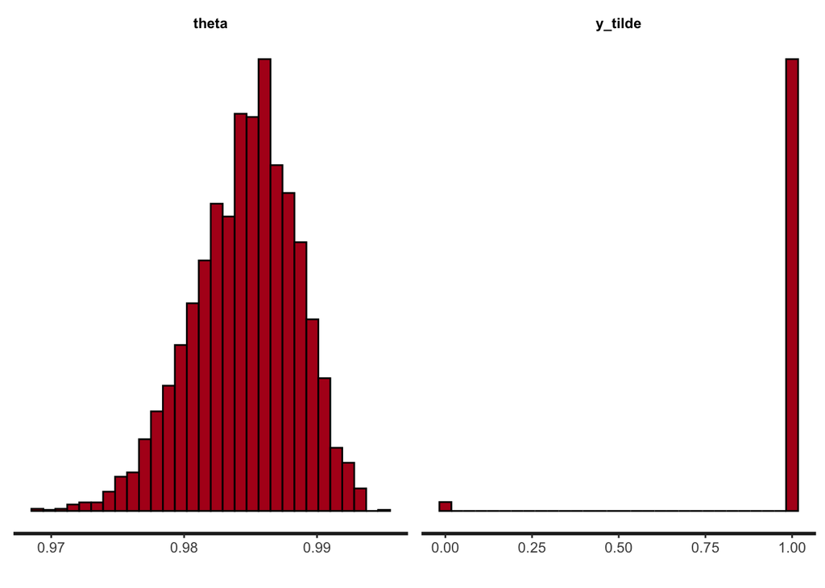

```r
quietgg(stan_hist(fit_bernoulli)) # Plot the approximated posterior density, suppressing warning messages
```

```r
#Calculate some statistics
thetamean<-get_posterior_mean(fit_bernoulli,pars="theta") #Get posterior mean of theta
```

## Interpretation and Monte Carlo Diagnostics

- Markov Chain Monte Carlo approximation drew 4 2000 sample sequences
  - “Warm up” or “Burn in” of 1000 means first 1000 draws are discarded: done to reduce bias from start point of chain
  - “Effective Sample Size” n_eff smaller than 4000 because samples autocorrelated, so variance increased, to level “as if” n_eff samples used
- Run multiple long chains to compare variability
  - If distribution very different across samples within chains or across chains, possible that sampler “got stuck”
  - Rhat not close to 1, warnings saying “divergent transition” or trace plots of MCMC draws which seem to wander around are all warning signs of problems with sampler
  - Use `launch_shinystan()` in library `shinystan` for extensive graphical summaries of fit and diagnostics
  - Due to randomness, can never be sure approximation is good, but should be cautious if warnings exist
- Data used had N= 985 1s, M= 15 0s
  - So with prior Beta(0.5,0.5), exact posterior on $\theta$ is Beta(985.5,15.5), with mean 0.9845155
- MCMC approximate posterior on $\theta$ had mean 0.9845791
  - Shape close to Beta distribution, but with some fluctuations due to sampling error
  - Could improve precision at cost of longer runtime by sampling longer chains

## Trace Plot of MCMC Chains

- Chains show similar and narrow variation, suggesting reasonably weak dependence

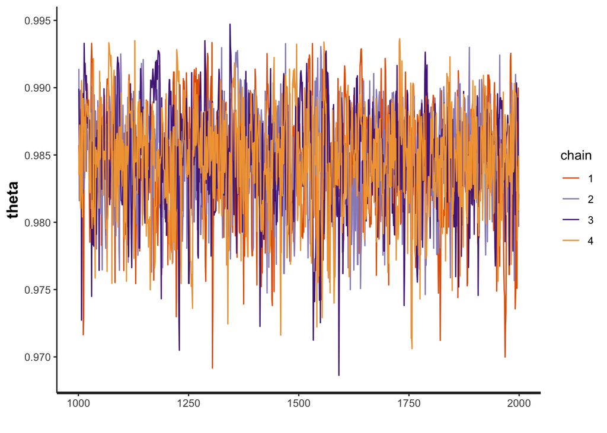

```r
traceplot(fit_bernoulli,pars="theta")
```

## Extending the Model

- For more practical application, can add dependence by making probability of drawing a 1 a function of past samples
- Let’s try Bayesian version of logistic autoregression model (as in recession forecast example)
  - $p(y_{t+1}=1|\mathcal{Y}_{t})=\text{logit}^{-1}(a+\beta_1 y_{t-1}+\beta_2 y_{t-2})$
  - iid Bernoulli model is special case where $\beta_1=\beta_2=0$, $\text{logit}^{-1}(a)=\theta$
- Need prior on $\beta$:
  - Note that $\text{logit}^{-1}(5)\approx0.99$, so unless very strong persistence expected, prior should mostly be within $[-5,5]$
  - Try N(0,10) for $a$, $N(0,5)$ for $\beta_1,\beta_2$, all independent, for quite dispersed prior
  - Allows reasonable chance of very high persistence, but doesn’t force it

## Stan Code

```r
stan_code_logitAR <- "
data {
  int T;                     // The sample size
  int<lower=0,upper=1> y[T]; // The observations (array of length T)
  int<lower=0> K;            // Number of lags to use
  real<lower=0> prior_a;     // Prior variance of intercept
  real<lower=0> prior_b;     // The variance of coefficients on lags
}
parameters {
  real a;                    // Intercept coefficient
  real b[K];                 // K Lag coefficients
}
model {
  a ~ normal(0,prior_a);        // Intercept Prior
  for (k in 1:K)
    b[k] ~ normal(0,prior_b);   // Lag coefficient priors
  for (t in (K+1):T) {
    real mu = a;
    for (k in 1:K)
      mu += b[k] * y[t-k];       // Formula is sum of intercept and lags
    y[t] ~ bernoulli_logit(mu);  // Likelihood
  }
}
generated quantities {
  int<lower=0,upper=1> y_tilde;  // Samples from posterior predictive distribution
  for (t in (T-K):T) {           // Use last K observations to predict y[T+1]
    real mu = a;
    for (k in 1:K)
      mu += b[k] * y[t-k];
    y_tilde = bernoulli_rng(inv_logit(mu));  //Simulate from conditional likelihood
  }
  }"
```

## Results: MCMC Fit vs Maximum Likelihood Fit

- Maximum likelihood here is logistic regression: ERM of cross-entropy loss
  - If Bernstein von Mises approximation close, prior doesn’t matter, and Std. Error here is Normal posterior standard deviation

```r
summary(recessionlogit)$coefficients #MLE
```

```
##              Estimate  Std. Error      z value     Pr(>|z|)
## (Intercept)  -3.69266   0.1762321 -20.95339369 1.747251e-97
## l1usrec      20.85563 476.3834345   0.04377909 9.650805e-01
## l2usrec     -14.42507 476.3834351  -0.03028038 9.758434e-01
```

- Examining MCMC fit with priors, big difference in coefficients

```r
print(fit_logitAR) #Bayesian Prediction
```

```
## Inference for Stan model: LogitARModel.
## 4 chains, each with iter=2000; warmup=1000; thin=1;
## post-warmup draws per chain=1000, total post-warmup draws=4000.
##
##            mean se_mean   sd    2.5%     25%     50%     75%   97.5% n_eff
## a         -3.70    0.00 0.18   -4.05   -3.81   -3.69   -3.58   -3.36  1582
## b[1]       9.33    0.07 1.84    6.66    7.98    9.03   10.33   13.75   727
## b[2]      -2.88    0.07 1.84   -7.31   -3.86   -2.55   -1.55   -0.20   715
## y_tilde    0.03    0.00 0.16    0.00    0.00    0.00    0.00    1.00  4064
## lp__    -283.23    0.05 1.33 -286.60 -283.81 -282.89 -282.26 -281.72   795
##         Rhat
## a          1
## b[1]       1
## b[2]       1
## y_tilde    1
## lp__       1
##
## Samples were drawn using NUTS(diag_e) at Mon Oct 28 00:00:23 2019.
## For each parameter, n_eff is a crude measure of effective sample size,
## and Rhat is the potential scale reduction factor on split chains (at
## convergence, Rhat=1).
```

## Posterior and Posterior Predictive Distribution Samples

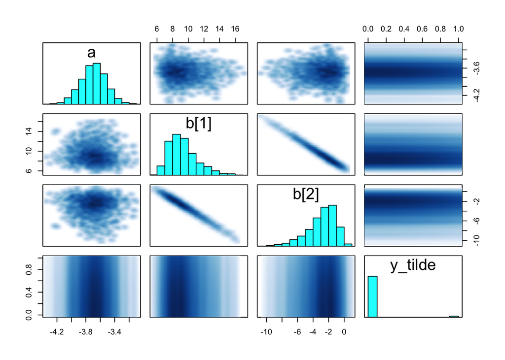

```r
#Pairs plot
pairs(fit_logitAR,pars=c("a","b","y_tilde"))
```

## Summary

- Bayesian approach offers principled and orderly way to produce predictions and forecasts
- Knowledge goes into building models and selecting priors: rest is just integration
  - But integration is hard!
- Can easily approximate posterior locally by its maximum, giving MAP equal to penalized ERM
- Can extend to distribution in large samples by taking Laplace approximation
  - Posterior close to normal around MAP, with variance defined by derivatives
- For small samples or challenging problems, can sample by Markov Chain Monte Carlo
  - Implement easily using probabilistic programming languages like Stan

## References

- Chi Feng [The Markov-chain Monte Carlo Interactive Gallery](https://chi-feng.github.io/mcmc-demo/) 2017
  - Visualizations showing how different MCMC algorithms construct samples
- Jim Savage [A quick-start intro to Stan for Economists](https://nbviewer.jupyter.org/github/QuantEcon/QuantEcon.notebooks/blob/master/IntroToStan_basics_workflow.ipynb) 2016
  - Practical introduction to Bayesian model building in Stan
- Chris Sims. [Bayesian Methods in Applied Econometrics, or, Why Econometrics Should Always and Everywhere Be Bayesian](http://sims.princeton.edu/yftp/EmetSoc607/AppliedBayes.pdf) 2007
  - A rant
- Stan Development Team. **[Stan User’s Guide](https://mc-stan.org/docs/2_18/stan-users-guide/index.html)** 2018, v 2.18
  - Comprehensive guide to Stan language and Bayesian models
- Aad van der Vaart. **Asymptotic Statistics** Cambridge UP, 1998
  - Has useful (but overly technical) chapters on Bayesian large sample approximations